# Final Project 216: Features for Weight Classification

Krish Rai

2024-03-20

## Introduction

Obesity/being overweight is a prominent risk factor globally for a variety of diseases, including heart disease, diabetes, and cancer. According to the CDC, Body Mass Index (BMI), or weight/height^2 is used to determine which weight category an individual falls under. A BMI under 18.5 is underweight, 18.5-24.9 is normal, 25-29.9 is overweight, and 30 or above is obese where all units are kg/m^2(1). There are classes to obesity as well: Level I is 30-34.9 kg/m^2, II is 35-39.9, and III is 40 or more (2).

It is known that age and height are correlated with how much an individual weighs. However, to understand the risks of individuals not being a healthy weight, it is essential to assess how their choices/lifestyle can affect their weight.

In the ‘Estimation of Obesity Levels Based On Eating Habits and Physical Condition’ from UC Irvine’s Data Repository, the daily habits of individuals in Mexico, Peru, and Colombia are shown with 2111 participants. This dataset has a high number of variables (p), many of which are categorical/binary survey answers. While it is not high dimensional as there are thousands of observations for under 20 variables, there are still many variables present that need to be utilized to predict weight class.

To make sense of this data, the key goal is to determine which of the provided variables of lifestyle habits are the 3 most important predictors (variable importance using a machine learning model) of weight class and which are the 3 least.

## Methods

In order to determine which variables are the most important to predict weight class, the data needed to be manipulated. Since the age and height range is broad, the data was subset to only include 20-40 year olds and 1.67m-1.83 m in height. The weight variable was excluded. Age, height, and weight were not predictors in the model, but gender was left in as a predictor.

There were 7 categories of weight: insufficient weight, normal, Overweight Levels I and II, and Obesity Levels I, II, and III. However, with the age and height range cut, there were under 800 rows of data. Additionally, the specific obesity levels were too precise and led to misclassification. Therefore, for the purposes of assessing weight class accurately, the categories were condensed to insufficient weight, normal weight, Overweight, and Obesity with the levels for Overweight and Obesity joining into the two overarching levels (outcome redefined as NObeyesdad3).

The data was split 70-30, training and testing respectively.

```r
#770 rows used
set.seed(21)
pros_shuffle <- final216[sample(770, size=770, replace=F),]
pros_train <- pros_shuffle[seq(539),]
pros_test <- pros_shuffle[seq(540, 770),]
```

This was a multiclass-categorical outcome classification, and the data had many variables which likely had relationships with each other. Many of these predictors were binary as well. With this information, it was suitable to use an ensemble method to learn and factor in all of these variables appropriately. Therefore, random forest was chosen, also useful as it randomly selects variables to reduce variance. This was done in two ways.

The first way was a random forest model. Expand.grid to account for multiple hyperparameters was posing issues in the code, so the various hyperparameter models were run individually to see which was the best. Accuracy was then calculated.

This model was then used to predict weight classification on the test set, and a confusion matrix was generated. The accuracy was as well.

The second method still utilized random forest as a method but also used cross validation, splitting into folds where a different fold is used as test set in each iteration before averaging the results. While this is a good method to prevent over fitting and improve generalization for the prediction, the amount of data was still limited. The results are shown.

## Results

The data features/predictors used in this random forest model are shown in Table 1 below. For categorical variables, the number present is shown and for continuous the median and interquartile range is shown.

### Table 1:Feature Characteristics

```r
library(gtsummary)
```

```r
sumtable <- final216 %>%
  tbl_summary(include = c(Gender, fam_hist, FAVC,FCVC, NCP, CAEC, SMOKE,SCC, CH2O, FAF, TUE, CALC,MTRANS)) %>%
modify_header(label = "**Table 1: Feature Characteristics**")
sumtable
```

| **Table 1: Feature Characteristics** | **N = 789**<sup>1</sup> |
| --- | --- |
| Gender |  |
| Female | 238 (30%) |
| Male | 551 (70%) |
| fam_hist | 723 (92%) |
| FAVC | 733 (93%) |
| FCVC | 2.32 (2.00, 3.00) |
| NCP | 3.00 (2.97, 3.00) |
| CAEC |  |
| Always | 18 (2.3%) |
| Frequently | 79 (10%) |
| no | 10 (1.3%) |
| Sometimes | 682 (86%) |
| SMOKE | 12 (1.5%) |
| SCC | 17 (2.2%) |
| CH2O | 2.00 (1.80, 2.40) |
| FAF | 1.00 (0.39, 1.73) |
| TUE | 0.69 (0.05, 1.00) |
| CALC |  |
| Always | 1 (0.1%) |
| Frequently | 35 (4.4%) |
| no | 213 (27%) |
| Sometimes | 540 (68%) |
| MTRANS |  |
| Automobile | 224 (28%) |
| Bike | 2 (0.3%) |
| Motorbike | 5 (0.6%) |
| Public_Transportation | 541 (69%) |
| Walking | 17 (2.2%) |

<sup>1</sup> n (%); Median (IQR)

```r
##TABLE 1
```

### Figure 1: Assessing Outcome Variable Count

The counts of each class are included to understand the breakdown of the outcome variable classes.

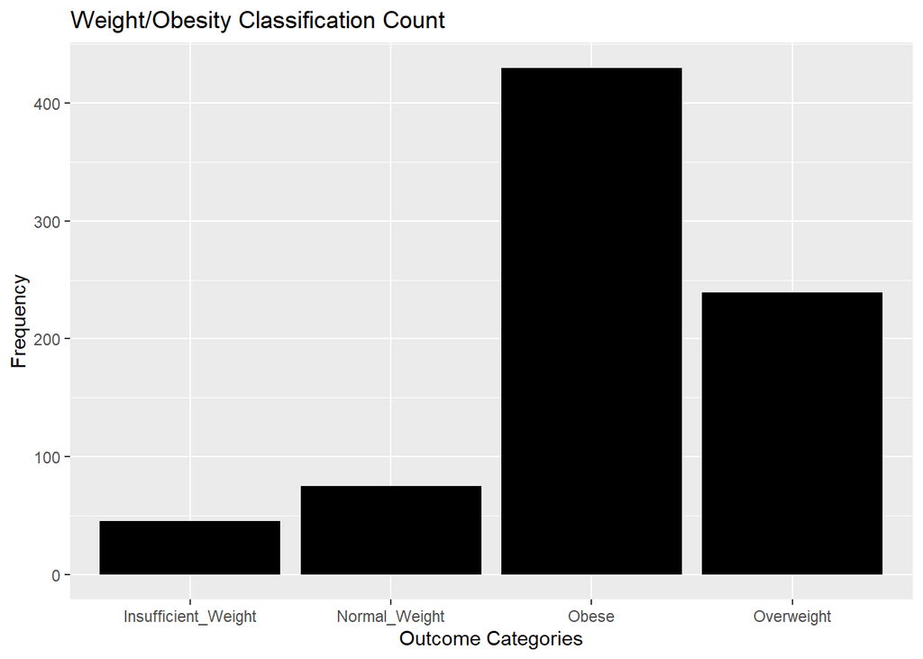

```r
ggplot(final216, aes(x=NObeyesdad3)) +
  geom_bar(fill="black") +
  labs(title = "Weight/Obesity Classification Count", x="Outcome Categories",y="Frequency")
```

```r
#Figure 1: Assessing Outcome Variable
```

The results for the random forest model are shown. The ranger package was used, and only the predictor variables were added for the model. The outcome variable was converted to a factor.

Accuracy, confusion matrix, sensitivity and specificity were calculated.

```r
set.seed(20)
WeightClass <- ranger(as.factor(NObeyesdad3) ~ Gender + fam_hist + FAVC + FCVC + NCP + CAEC + SMOKE + CH2O + SCC + FAF + TUE + CALC + MTRANS, data=pros_train, importance = "impurity", mtry = 3, num.trees = 500)

#First is best. Stick with Weightclass. Accuracy is
1-WeightClass$prediction.error
```

```
## [1] 0.825603
```

This was repeated with models with mtry (number of trees per variable) of 5 and 10 and number of trees of 1000 to tune. While the prediction error varies slightly, the mtry=3 and num.trees = 500 was chosen as it produced the lowest error. This was used for the next step.

### Table 2: Confusion Matrix for Random Forest

Predict!

```r
library(caret)
fact_prostest <- as.factor(pros_test$NObeyesdad3)
true_test <- as.numeric(as.factor(pros_test$NObeyesdad3))

PredictWeight <- predict(WeightClass, pros_test)

predicted_test <- as.numeric(PredictWeight$predictions)
results <- confusionMatrix(table(predicted_test, true_test))

print(results$table)
```

```
##               true_test
## predicted_test   1   2   3   4
##              1  13   0   0   0
##              2   0  11   3   5
##              3   0   2 118  12
##              4   1   7  11  48
```

```r
#Table 2: Confusion Matrix for Random Forest
```

Most were classified correctly.

```r
set.seed(20)
stats1 <- confusionMatrix(PredictWeight$predictions,fact_prostest)

stats1$overall[1]
```

```
##  Accuracy
## 0.8225108
```

### Table 3: Sensitivity and Specificity Stats

```r
stats1$Tableclass <- as.data.frame(stats1$byClass)

stats1$Tableclass[1:2]
```

```
##                            Sensitivity Specificity
## Class: Insufficient_Weight   0.9285714   1.0000000
## Class: Normal_Weight         0.5500000   0.9620853
## Class: Obese                 0.8939394   0.8585859
## Class: Overweight            0.7384615   0.8855422
```

```r
#Table 3: Sensitivity and Specificity Stats
```

### Figure 2: Variable Importance (Results)

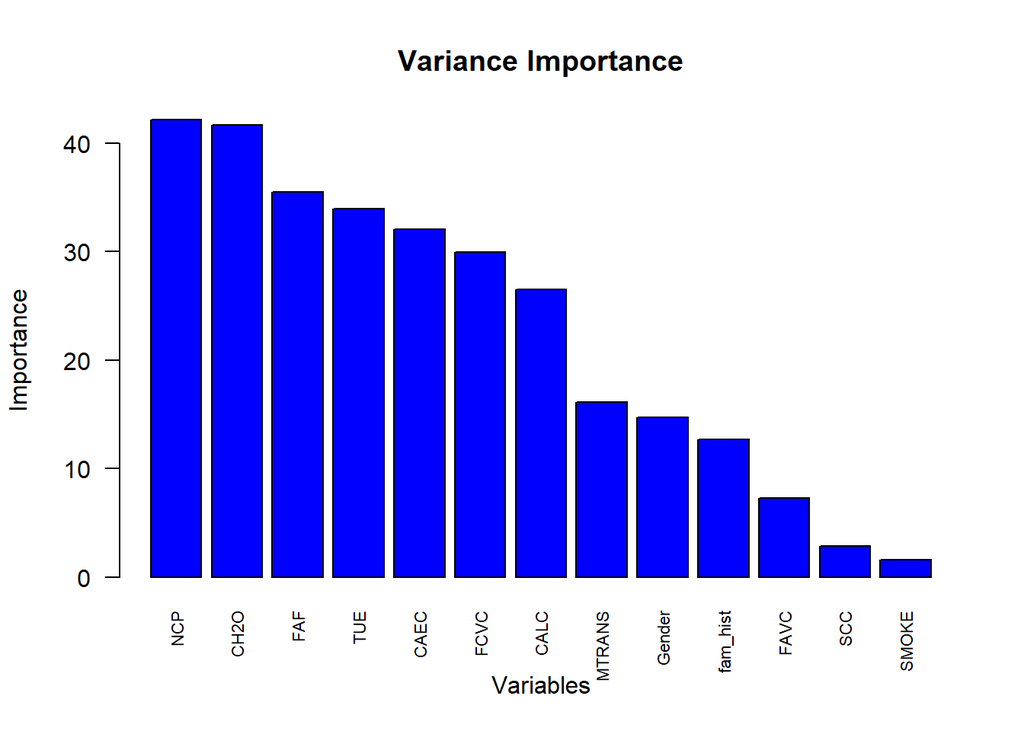

```r
#For self https://www.geeksforgeeks.org/variable-importance-plot-using-random-forest-package-in-r/

sort_WeightClass <- sort(WeightClass$variable.importance, decreasing = TRUE)
barplot(sort_WeightClass, main= "Variance Importance", xlab= "Variables", ylab = "Importance",col="blue", las =2, cex.names=0.70)
```

```r
#Figure 2: Variable Importance (Results)
```

Variable importance plot is shown. The results show that the following variables were most important in predicting: CH20 (how much water one drinks daily), NCP (how many main meals daily), and FAF (how often one has physical activity). The least important were FAVC (eat high caloric food frequently), SCC (monitor the calories eaten daily), and SMOKE (whether one smokes).

### Table 4:Accuracy for hyperparameters of Cross Validated Random Forest Model

Cross validation (3) was also used with random forest to potentially help curb overfitting and improve the model.

```r
library(caret)
set.seed(7)
tc <- trainControl(method = "cv", number = 3)

rfcv <- train(as.factor(NObeyesdad3) ~ Gender + fam_hist + FAVC + FCVC + NCP + CAEC + SMOKE + CH2O + SCC + FAF + TUE + CALC + MTRANS, data=pros_train, method = "rf", trControl = tc, importance = TRUE)

rfcv$results[,1:2]
```

```
##   mtry  Accuracy
## 1    2 0.7346576
## 2   11 0.8033726
## 3   20 0.7977861
```

```r
#Table 4:Accuracy for hyperparameters of Cross Validated Random Forest Model
```

### Table 5: Confusion Matrix for Cross Validation Method

```r
pros_testfinalcv <- as.numeric(as.factor(pros_test$NObeyesdad3))
fact_prostestcv <- as.factor(pros_test$NObeyesdad3)

PredictWeightcv <- predict(rfcv, pros_test)

numPredictWeightcv <- as.numeric(PredictWeightcv)
results2 <- confusionMatrix(table(numPredictWeightcv, pros_testfinalcv))

print(results2$table)
```

```
##                   pros_testfinalcv
## numPredictWeightcv   1   2   3   4
##                  1  12   0   0   1
##                  2   2  12   3   3
##                  3   0   3 115  10
##                  4   0   5  14  51
```

```r
#Table 5: Confusion Matrix for Cross Validation Method
```

```r
results2$overall[1]
```

```
##  Accuracy
## 0.8225108
```

The results were about the same than the regular random forest in terms of accuracy. Therefore, the first random forest model data was kept.

## Discussion:

The findings show: water drank daily, number of meals, and physical activity as the most important variables in the model. This seems like a reasonable result as these variables are directly correlated with weight. The weakest variables are FAVC (eats high caloric food frequently), SCC (monitor the calories eaten daily), and SMOKE (whether one smokes).

Although grouping variables, trying cross validation, as well as different hyperparameter tunings of the forest were tried and did impact slightly, there were still issues. Specific location (urban/rural) in these countries and health were not directly part of study (although family history of obesity was), and these categorical predictors were also limited due to the amount of data. Since the goal was to figure out variable importance, a wide range of ages and heights would likely confound and so the amount of data was reduced from 2100 to under 800 rows to fall between certain age and height range. With more data available in these specific ranges, we could see if accuracy improves.

Additionally, survey based categorical data is inherently prone to information and survey bias so other quantitative checks for the predictors (how much they eat by tracking) would help. Another issue was that there were more obese and overweight subjects than normal or insufficient weight ones.

Nevertheless, this data does give an insight on factors related to obesity/weight classification. The accuracy was acceptable, and the most important variables for predicting weight classification were found. For next steps, it may be useful to find a larger dataset with a population over a narrow age and location range. Additionally, many of these categorical variables could also be measured with continuous predictors (tracking how much water, how many meals participants consume over the course of a week). This could help improve the model. However,this model does help shed light on predictors and their influence on weight class.

## Citations:

1.Centers for Disease Control and Prevention. (2022, June 3). About adult BMI. Centers for Disease Control and Prevention. https://www.cdc.gov/healthyweight/assessing/bmi/adult_bmi/index.html 2.Weir, C. B., & Jan, A. (2023, June 26). BMI Classification Percentile And Cut Off Points. PubMed; StatPearls Publishing. https://www.ncbi.nlm.nih.gov/books/NBK541070/ 3.Wright, M., Wager, S., Probst, P., & Maintainer. (2021). Package “ranger” Type Package Title A Fast Implementation of Random Forests. https://cran.r-project.org/web/packages/ranger/ranger.pdf

Dataset: https://archive.ics.uci.edu/dataset/544/estimation+of+obesity+levels+based+on+eating+habits+and+physical+condition